# Building Blocks of Political Science

POLS 2140: Introduction to Political Analysis

Sarah Dreier

## Announcements

- **Local internship workshop**: Wed Aug 26, 3:00-4:00 pm at Social Sciences 2060
- **Political Science open house**: Wed Aug 26, 4:00-5:30 pm at Social Sciences Floor 2
- Sign up for your Data News presentation (by Fri Aug 28) via Canvas Pages!

[figure not shown]

## Reading Prompt

What is one “rule of the road” the chapter discussed? In your own words, why is it important for the practice of political science?

What does it mean to approach understanding politics as a *scientific* exercise?

## What is political science?

The scientific study of **political phenomena.**

### Political phenomena:

1. People’s **political behavior**: votes, tweets, campaign promises, political attitudes, protesting, etc.
2. **Government power**, including to write/enforce laws and policies, detain/restrict behavior, use violence.
3. **Who governs whom** (and how that impacts those who are governed).
4. **Distribution of legitimacy and resources**.
5. **Interactions between/within political state boundaries** — how states relate to one another, and how individuals relate to political institutions.

## JOT DOWN specific examples of:

1. Your own **political behavior** (voting, protests, blog posts, etc.).
2. A time when you (or someone close to you) experienced **government power**.
3. How someone or something **“governs”** your behavior.
4. How you were impacted by how resources are distributed or how identities are (de)legitimized
5. A time **states and/or countries interacted with one another** in a way that affected your life.

## What is political science?

The **scientific study** of political phenomena.

- Exploring and testing the relationships between observable “variables.”
- With one variable, I can describe something going on in the world.

**Describe** a circumstance:

- In 2024, about 27% of national parliamentarians are women. (Inter-Parliamentary Union, 2024)
- 25.1% of countries for which 2024 data is available have 1/3 or more of their parliamentary seats held by women. (World Bank Group, 2024)
- What observations can you make with this information?
- What questions does this information spark for you?

Proportion of Seats Held by Women in National Parliaments Over Time (%)

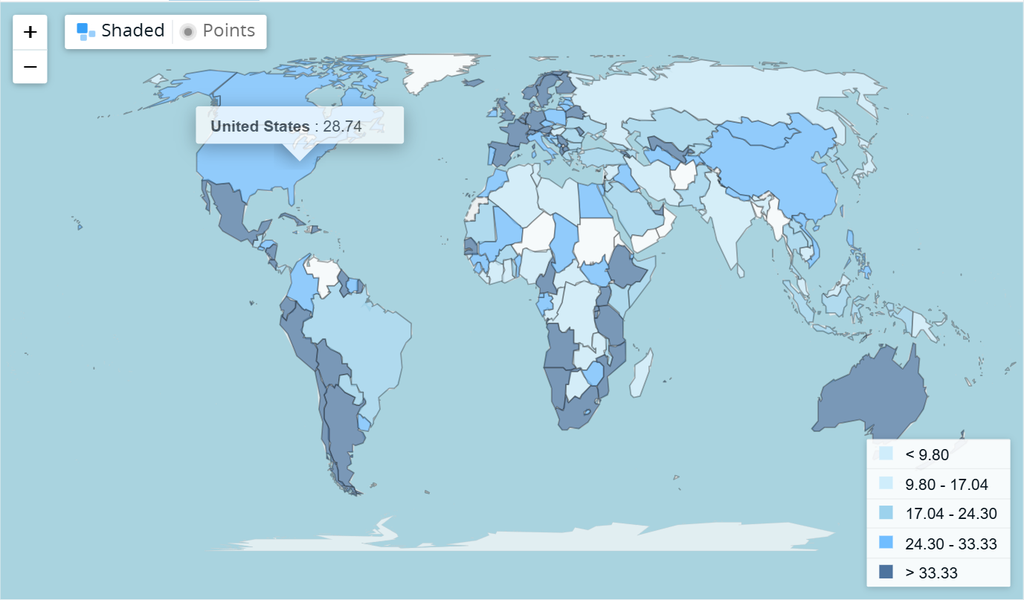

Source: World Bank Group

## The stats: National parliamentarians

Today: Only 27% of parliamentarians are women (Inter-Parliamentary Union, 2024)

Some variation across continents.

No clear association between a country’s wealth and representation.

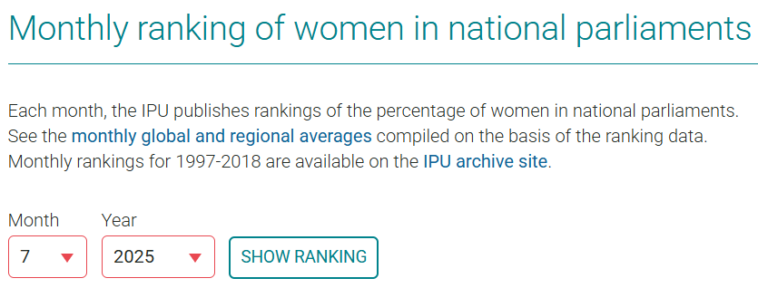

Proportion of Seats Held by Women in National Parliaments by Region (%)

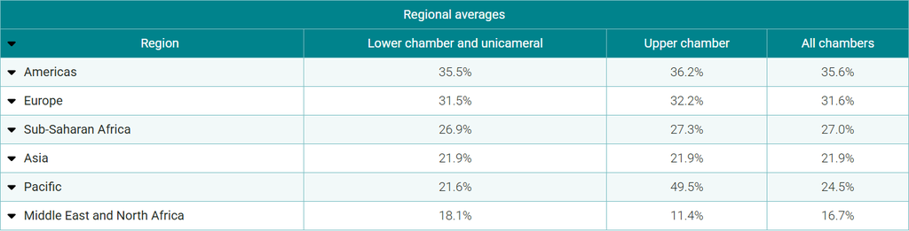

Source: IPU Parline

## UPDATE: Women in National Parliaments (2026)

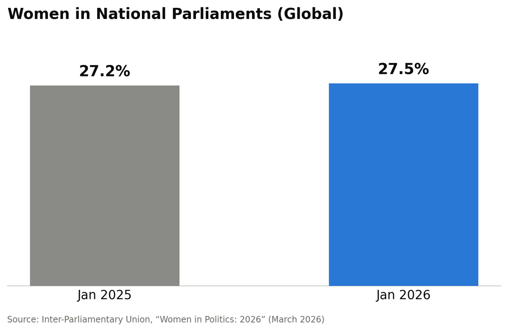

- Growth has slowed to its lowest rate since 2017 — at this pace, global gender parity is roughly 75 years away
- The Americas remain the highest-representation region, at 35.6%

(Inter-Parliamentary Union, 2026)

## The stats: LGBTQ+ elected officials

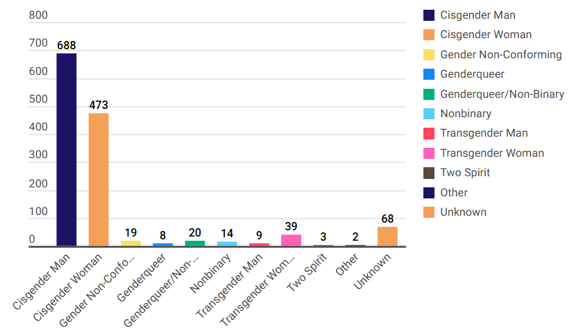

2025 US Elected Officials (0.26% LGBTQ+, Source: LGBTQ+ Victory Institute):

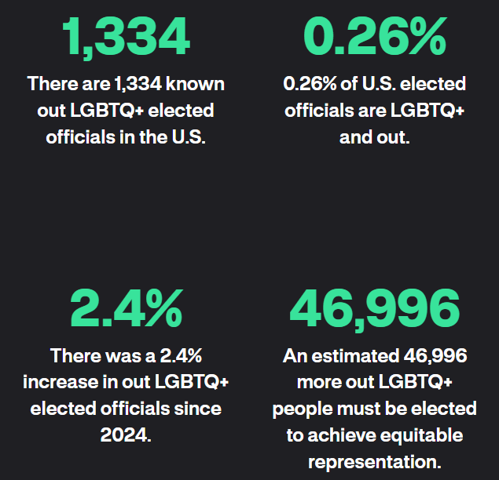

In the US 2025: (Source: LGBTQ+ Victory Institute)

## UPDATE: LGBTQ+ Elected Officials (2026)

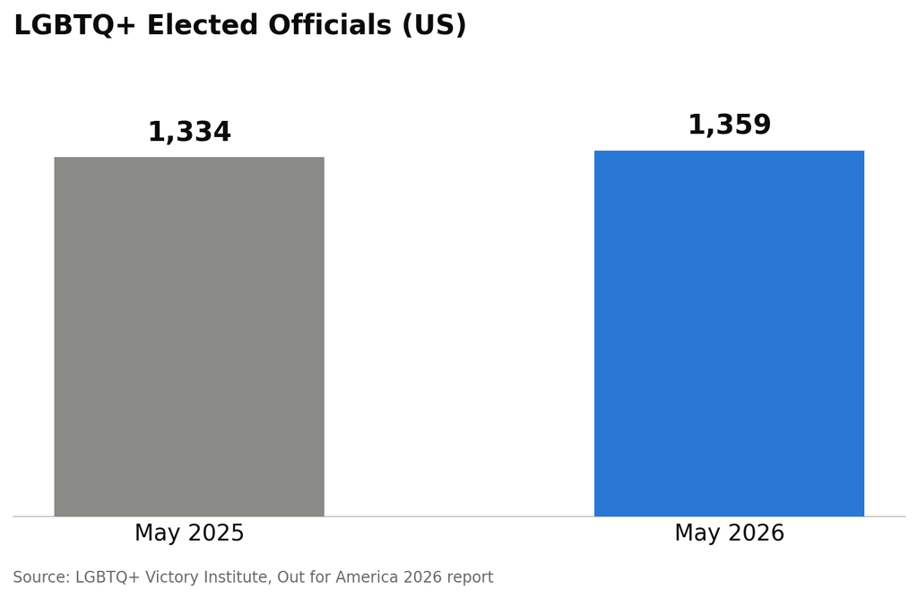

- Up from 1,334 the prior year — modest continued growth
- Some researchers argue this report still **undercounts** LGBTQ+ officials, particularly in California — worth remembering as we discuss how data is never fully “raw” or neutral

(Victory Institute, 2026)

## The stats: Heads of state

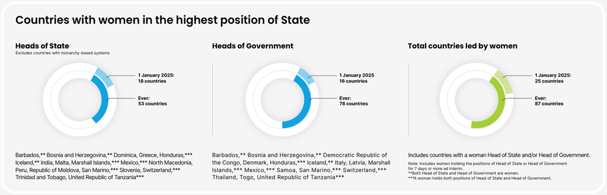

Source: UN Women

## The stats: Heads of state

- 60 UN member states (31%) have had women heads of state (Pew Research Center, 2024)

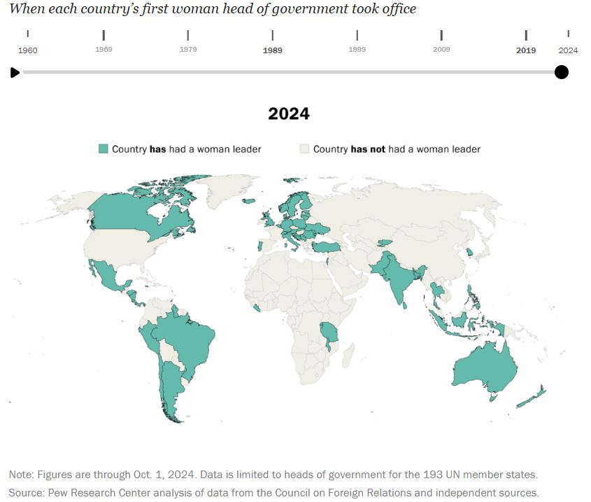

[figure not shown]

## UPDATE: Women Heads of State (2026)

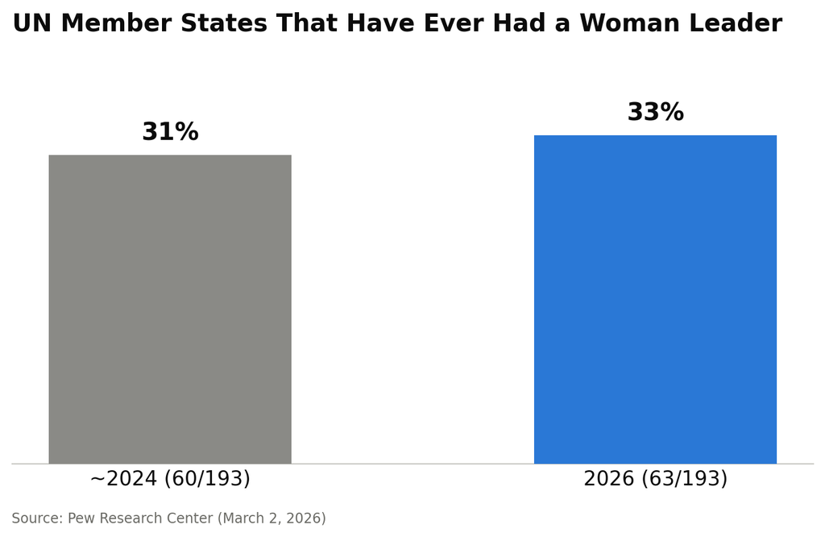

- 63 of 193 UN member states have now *ever* had a woman leader — up from 60
- For comparison: as of January 2026, only 28 countries are **currently** led by a woman — just 1 in 7 worldwide

(Pew Research Center, 2026)

## Resources and interactive data portals

- **UN Women** — [Women’s leadership and political participation](https://www.unwomen.org/en/what-we-do/leadership-and-political-participation/facts-and-figures) (facts, figures, and infographic)
- **IPU Parline** — [Global data on women in national parliaments](https://data.ipu.org/women-ranking/)
- **World Bank Data** — [Proportion of seats held by women in national parliaments](https://data.worldbank.org/indicator/SG.GEN.PARL.ZS)
- **Pew Research Center** — [Women heads of state](https://www.pewresearch.org/short-reads/2024/10/03/women-leaders-around-the-world/)
- **LGBTQ+ Victory Institute** — [LGBTQ+ U.S. elected officials (2024)](https://victoryinstitute.org/out-for-america-2024/)

## What is political science?

The **scientific study** of political phenomena.

- Exploring and testing the relationships between observable “variables.”
- **With one variable,** I can describe something going on in the world.
- **With two variables,** I can begin to explain **why** that thing is the way it is: causation.

Beginning to capture causation can help us understand how things come about and what social or policy changes could lead to **new** outcomes.

How does this new information shift your original observations?

Does this mean that an increase in **time causes** an increase in **women’s representation?**

Or is there something else that maybe also increases with time that is the real cause of women’s representation?

Proportion of Seats Held by Women in National Parliaments Over Time (%)

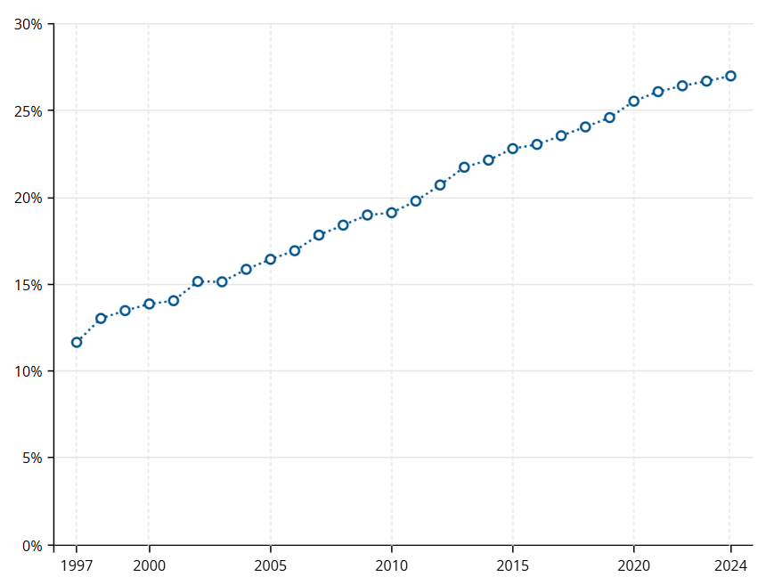

Source: World Bank Group

## What is political science?

The **scientific study** of political phenomena.

- Exploring and testing the relationships between observable **“variables.”**
- **Dependent Variable (DV, Y)** — the outcome you want to explain; the thing that **depends on** (is influenced by) something else.
- **Independent Variable (IV, X)** — the thing you think influences your DV; in theory the IV should “come before” your DV (reality is not that simple).

What kinds of causal relationships might you expect?

- % women as the DV?
- % women as the IV?

Proportion of Seats Held by Women in National Parliaments Over Time (%)

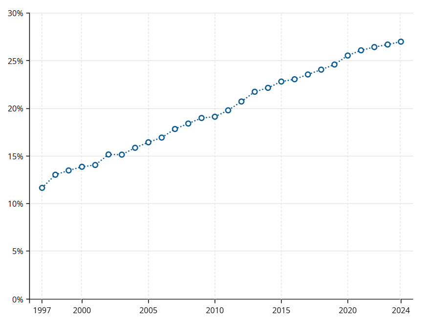

Source: World Bank Group

## What is political science?

The **scientific study** of political phenomena.

- Exploring and testing the **relationships** between observable **“variables.”**
- **Dependent Variable (DV, Y)** — the outcome you want to explain; the thing that **depends on** (is influenced by) something else.
- **Independent Variable (IV, X)** — the thing you think influences your DV; in theory the IV should “come before” your DV.
- **Hypothesis** — your guess about the relationship between IV and DV: if X happens, then Y will follow; if we see an increase in X, we should see an (increase/decrease) in Y.

## WEEKLY ASSIGNMENT (due this Sunday)

- What are 2–3 political outcomes (**dependent variables**) that matter to you?
- For one of these topics, what is one thing (**independent variable**) that helps explain, shape, or influence your outcome?
- Come up with a guess (a **hypothesis**) about the direction of influence your IV might have on your DV.

## Tuesday’s Reading

[figure not shown]

[figure not shown]

These are blogs for social scientists to present their research to a public audience. Select and read an article that interests you from **[Good Authority](https://goodauthority.org/)** (most recommended) or an [LSE blog](https://blogs.lse.ac.uk/). Identify the author’s IV, DV, and conclusion, and be prepared to discuss in class on Tuesday.

## TL;DR

- Political science is the **scientific study of political phenomena** — people’s political behavior; government power; who governs whom; allocation of resources and legitimacy; and interactions between states, institutions, and individuals
- With **one variable** you can describe what’s happening in the world; with **two variables** (an IV and a DV) you can start to explain *why* — that’s the move into causal reasoning
- A **hypothesis** is a testable guess about how your IV influences your DV — the backbone of the research process we’ll use all semester
- Real-world data (e.g., women’s political representation) shows both progress and persistent inequities — and even good, well-sourced data has limits and undercounts worth interrogating
- **For Tuesday**: read a political science blog post and identify the author’s IV, DV, and conclusion

## References

Inter-Parliamentary Union. (2024). *Women in parliament in 2023: The year in review*. Inter-Parliamentary Union. https://www.ipu.org/resources/publications/reports/2024-03/women-in-parliament-in-2023-the-year-in-review

Inter-Parliamentary Union. (2026, March). *Women in politics: 2026*. https://www.ipu.org/resources/publications/infographics/2026-03/women-in-politics-2026

Pew Research Center. (2024, October 3). *Women leaders around the world*. https://www.pewresearch.org/short-reads/2024/10/03/women-leaders-around-the-world/

Pew Research Center. (2026, March 2). *About 1 in 3 UN member states have ever had a woman leader*. https://www.pewresearch.org/short-reads/2026/03/02/about-a-third-of-un-member-countries-have-ever-had-a-woman-leader/

Victory Institute. (2025). *Out for america 2025: A census of out LGBTQ+ elected officials nationwide*. LGBTQ+ Victory Institute. https://victoryinstitute.org/out-for-america-2025/

Victory Institute. (2026). *Out for america 2026: A census of out LGBTQ+ elected officials nationwide*. LGBTQ+ Victory Institute. https://outforamerica.org/

World Bank Group. (2024). *Proportion of seats held by women in national parliaments (% of total)*. https://data.worldbank.org/indicator/SG.GEN.PARL.ZS?start=2024&end=2024&view=map.